# Week 4: Agentic AI - Part 1

Applied Generative AI for AI Developers

Amit Arora

## Need for Agents

- In-context learning alone is not sufficient
  - Limited to input token size
  - No ability to retain context beyond a single session
- Why RAG (Retrieval-Augmented Generation) is not sufficient
  - Primarily enhances knowledge retrieval
  - Lacks decision-making and action-taking capabilities
- Agents extend LLMs by enabling them to interact with external tools and maintain long-term context

## The progression to Agents

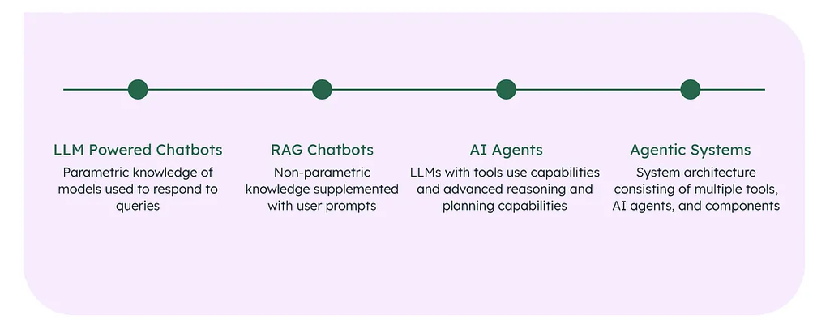

progression to agents

Source: [Mongodb](https://www.mongodb.com/pt-br/library/resources/ai-agents?x=inokiP)

## Tool Usage and Function Calling

- Agents leverage tool usage (aka function calling) to interact with external systems
- Function calling allows LLMs to:
  - Retrieve real-time data (APIs, databases)
  - Execute operations (calculations, file manipulations, etc.)
  - Make multi-step decisions by chaining function calls

## Introduction to AI Agents

- AI agents are autonomous programs.
- They observe their environment, make decisions, and take actions to achieve specific goals.
- Growing rapidly due to demand for automation and advances in NLP.

## AI Agent Processing Cycle

- **Input:** Gather and process information from the environment.
- **Decision:** Evaluate inputs against objectives using ML models (NLP, sentiment analysis, etc.).
- **Action:** Execute actions through output interfaces.
- **Learning:** Improve performance over time through feedback loops and learning mechanisms.

## Types of AI Agents

- Simple Reflex Agents
- Model-Based Reflex Agents
- Goal-Based Agents
- Learning Agents
- Utility-Based Agents
- Hierarchical Agents
- Multi-Agent Systems

## Simple Reflex Agents

- Decisions based solely on current sensory input.
- Respond immediately to environmental stimuli.
- Governed by condition-action rules.

### Key Components

- **Sensors:** Gather environmental information.
- **Condition-Action Rules:** Predefined responses to specific inputs.
- **Actuators:** Execute decisions.

### Use Cases

- Industrial safety sensors
- Automated sprinkler systems
- Email auto-responders

## Model-Based Reflex Agents

- Maintain an internal model of the world.
- Infer unobserved aspects of the current state.
- Use the world model to make better decisions.

### Key Components

- **State Tracker:** Maintains information about the current state.
- **World Model:** Contains knowledge of how the environment evolves.
- **Reasoning Component:** Determines actions based on the world model.

### Use Cases

- Smart home security systems
- Quality control systems
- Network monitoring tools

## Goal-Based Agents

- Pursue specific objectives.
- Plan sequences of actions to achieve desired outcomes.
- Use search and planning algorithms.

### Key Components

- **Goal State:** A clear description of the agent’s aim.
- **Planning Mechanism:** Searches possible action sequences.
- **State Evaluation:** Assesses potential future states.
- **Action Selection:** Chooses actions based on their contribution to reaching the goal.
- **World Model:** Understanding of how actions change the environment.

### Use Cases

- Industrial robots
- Automated warehouse systems
- Smart heating systems
- Inventory management systems
- Task scheduling systems

## Learning Agents

- Improve behavior over time through experience.
- Modify behavior based on feedback.
- Learn how to achieve goals through experience.

### Key Components

- **Performance Element:** Selects external actions.
- **Critic:** Provides feedback on performance.
- **Learning Element:** Improves the performance element.
- **Problem Generator:** Suggests exploratory actions.

### Use Cases

- Industrial process control
- Energy management systems
- Customer service chatbots
- Quality control systems

## Utility-Based Agents

- Make decisions by evaluating potential outcomes.
- Choose actions that maximize overall utility.
- Handle tradeoffs between competing goals.

### Key Components

- **Utility Function:** Maps states to numerical values.
- **State Evaluation:** Assesses states in terms of their utility.
- **Decision Mechanism:** Selects actions to maximize utility.
- **Environment Model:** Understanding of how actions affect utility.

### Use Cases

- Resource allocation systems
- Smart building management
- Scheduling systems

## Hierarchical Agents

- Structured in a tiered system.
- Higher-level agents manage lower-level agents.
- Breaks down complex tasks into subtasks.

### Key Components

- **Task Decomposition:** Breaks down complex tasks.
- **Command Hierarchy:** Defines control flow.
- **Coordination Mechanisms:** Ensures agents work together.
- **Goal Delegation:** Translates objectives into tasks.

### Use Cases

- Manufacturing control systems
- Building automation
- Robotic task planning

## Multi-Agent Systems (MAS)

- Multiple autonomous agents interacting in a shared environment.
- Work independently or cooperatively.
- Focus on relatively simple agents interacting through basic protocols.

### Types of MAS

- **Cooperative:** Agents share information to achieve common goals.
- **Competitive:** Agents compete for resources.
- **Mixed:** Combines cooperative and competitive behaviors.

### Key Components

- **Communication Protocols:** Define information exchange.
- **Interaction Rules:** Specify how agents can interact.
- **Resource Management:** Handles shared resources.
- **Coordination Mechanisms:** Organizes agent activities.

### Use Cases

- Warehouse management
- Basic manufacturing
- Resource allocation

## Short-term vs. Long-term Memory

- **Short-term memory**: Stored during an active session (e.g., chat history)
- **Long-term memory**: Persisted across multiple sessions (e.g., user preferences, embeddings in a vector database)
- Agents utilize memory to enhance contextual understanding and improve decision-making

## Maintaining State and Session Information

- Techniques used by agents to manage state:
  - Context window retention (short-term memory)
  - Vector databases for retrieving past interactions
  - External storage (e.g., databases, knowledge graphs)
- Enables multi-tool collaboration and seamless user interactions

## Multi-Agent Collaboration

- Agents can work together to solve complex problems
- Examples:
  - One agent retrieves data while another analyzes it
  - Different agents specializing in distinct tasks (e.g., research, summarization, coding)
- Requires a shared state or communication mechanism

## Multi-Agent Collaboration

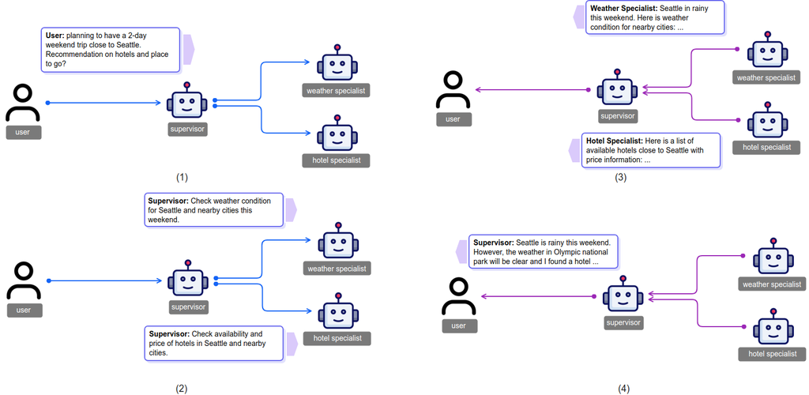

MAC

## Agent Frameworks - Open Source

- LangChain
- LlamaIndex
- AutoGPT
- CrewAI

## Agent Frameworks - AWS Solutions

- Amazon Bedrock Agents
- Step Functions + LLMs for orchestration

## Deploying Agents

- Agents can be exposed as APIs for integration into applications
- Key considerations:
  - Hosting (serverless, containers, on-premise)
  - Security (authentication, authorization)
  - Scalability and cost management
- Example: Deploying a customer support agent via API

## AI Agents stack

[figure not shown]

Agent stack

Source: [letta](https://www.letta.com/blog/ai-agents-stack)

## Summary

- Agents extend LLM capabilities by enabling tool usage, maintaining memory, and collaborating
- Different types of agents exist, each suited for specific tasks
- Memory and state management are crucial for effective agent performance
- Multi-agent collaboration allows for more sophisticated problem-solving
- Various frameworks and deployment strategies exist to implement agents in real-world applications

## References

- AutoGPT: https://github.com/Torantulino/Auto-GPT
- BabyAGI: https://github.com/yoheinakajima/babyagi
- LangChain: https://github.com/hwchase17/langchain
- LlamaIndex: https://github.com/run-llama/llama_index
- CrewAI: https://github.com/crewAI/crewAI
- AWS Bedrock Agents: https://aws.amazon.com/bedrock/
- AWS Step Functions: https://aws.amazon.com/step-functions/
- https://aws.amazon.com/blogs/machine-learning/unlocking-complex-problem-solving-with-multi-agent-collaboration-on-amazon-bedrock/
- https://medium.com/@vipra_singh/ai-agents-introduction-part-1-fbec7edb857d
- https://www.letta.com/blog/ai-agents-stack